# Environmental indicator analysis-Tilefish

```r
# Loading packages and data
library(ggplot2)
library(ecodata)
library(lubridate)
library(dplyr)
library(stringr)
library(marmap) # bathymetry
library(RColorBrewer)
library(ggnewscale)
library(sf)
library(cowplot)
library(tidyverse)
library(ggpubr)
library(sf)
library(ggdist)
library(ggpubr)
library(wesanderson)
library(raster)
#library(glmTMB)
library(ggpmisc)
library(mgcViz)
library(gratia)

# CPUE data (no env covariates)
gt_data_model_cpue <- read.csv(here::here('data/catch_data/gt_data_model_cpue.csv'))
#names(gt_data_model_cpue) <- tolower(names(gt_data_model_cpue))
# Add in column with cpue
# note: Paul indicated to use small mesh
gt_data_model_cpue <- gt_data_model_cpue %>%
       rename_all(., .funs = tolower) %>%
  mutate(mesh_bin = case_when(mesh_size <= 5.6 ~ 'SM',mesh_size >= 5.6 ~ 'LG',
                                                      TRUE ~ 'NA')) %>%
  mutate(cpue_hr = sum_gt_catch/effort_dur)

# Catch data:
sfobs <-readRDS(here::here('data/catch_data/gold_tile_sf_ob_v1_temp_price.rds'))

sfob.env <- sfobs %>%
  mutate(mesh_bin = case_when(mesh_size <= 5.6 ~ 'SM', mesh_size >= 5.6 ~ 'LG',
                              TRUE ~ 'NA'),
         cpue_hr = SUM_GT_CATCH/effort_dur) %>%
  filter(YEAR %in% c(1998:2022) & mesh_bin == 'SM') %>%
  dplyr::select(DATE, YEAR, MONTH, YDAY,trip_id,hull_num, area, effort_dur,
         SUM_GT_CATCH, cpue_hr, mesh_size, mesh_bin, depth, start_lat, start_lon,
         bottomT, bottomT_avg, MIN_TEMP_C, MEAN_TEMP_C, MAX_TEMP_C,
         TEMP_VARIANCE, TEMP_DEVIATION, MEAN_DPTH_M, tri, sed) %>%
  mutate(YEAR = as.integer(YEAR)) %>%
  rename_all(., .funs = tolower)


areas <- sort(unique(sfob.env$area))
catch.tally.ann <- sfob.env %>% # aggregate by year
  group_by(year) %>%
  summarise(ttl_sum = sum(sum_gt_catch))

# Length data from observer program
lengths <- read.csv(here::here('data/catch_data/gt_data_length_andy.csv'))
names(lengths) <- tolower(names(lengths))

# Recruitment estimates from 2021 report
recruit <- read.csv(here::here('data/assessment_data/tilefish_rec_estimate_2021.csv'))

# Merge SF/Obs catch data with recruit estimates:
catch_recruit <- cbind(recruit %>% filter(year %in% c(1998:2020)),
                       catch.tally.ann %>%
                         filter(year %in% c(1998:2020)) %>%
                         dplyr::select(ttl_sum))

# loading in shape files for maps
US.areas <- st_read(here::here('shapefiles/USA.shp'), quiet = TRUE)
canada.areas <- st_read(here::here('shapefiles/Canada.shp'), quiet = TRUE)
bts_strata <- st_read(here::here('shapefiles/NES_BOTTOM_TRAWL_STRATA.shp'),
                      quiet = TRUE)
# plot(bts_strata) # to see all bottom trawl strata

gtf_strata <- bts_strata %>%
  filter(STRATUMA %in% c('01030', '01040', '01070', '01080', '01110', '01120',
                         '01140', '01150', '01670', '01680', '01710', '01720',
                         '01750', '01760')) # select just the gtf strata
# plot(gtf_strata)
bathy <- marmap::getNOAA.bathy(-81,-58, 27, 46)
bathy = fortify.bathy(bathy)
```

### Recruitment estimate

Figure 3. Age-1 recruitment estimate from the 2021 tilefish assessment across all years

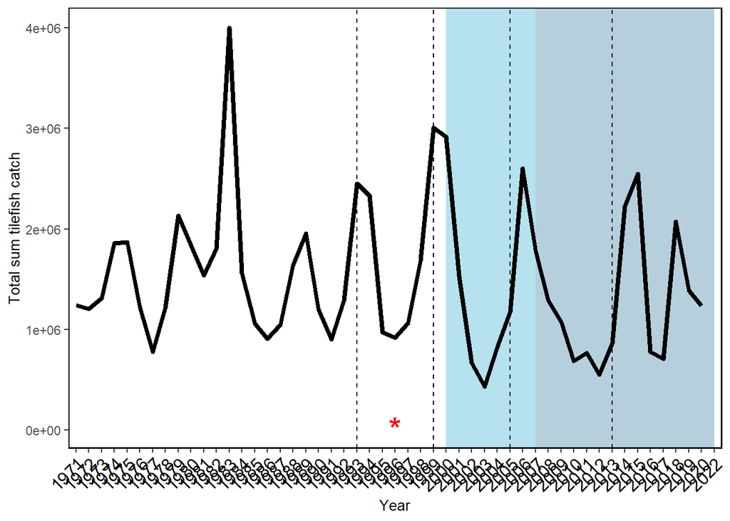

```r
ggplot(recruit, aes(x = factor(year), y = recruit_est, group = 1))+
   geom_rect(aes(xmin = '2007', xmax = '2022', ymin = -Inf, ymax = Inf),
            fill = 'red', alpha = 0.02) +
  geom_rect(aes(xmin = '2000', xmax = '2022', ymin = -Inf, ymax = Inf),
            fill = 'lightblue', alpha = 0.05) +
   geom_vline(xintercept = c('1993','1999', '2005', '2013'), lty = 2) +
  geom_line(color = 'black', size = 1.5) +
  annotate("text", label = "*",
    x = 26, y = 14000, size = 8, colour = "red" )+
  xlab('Year') +
  ylab('Total sum tilefish catch') +
  # facet_wrap(~month)+
  theme(axis.text.x = element_text(color = 'black',
                                   size = 12, angle = 45, vjust = 1, hjust=1)) +
  ecodata::theme_facet()
```

```r
### Thought: Should we isolate years associated w/strong year classes (or bad)
###           for correlations and analyses?
```

##### SST

```r
# SST
sst<-read.csv(here::here('data/sst/sst_ts_gtf_strata.csv'))
```

```r
# SST with year lag
sst.lag <- sst %>%
  mutate(mean_sst_lag1 = lag(weighted_mean_sst,12))

# Join with recruit estimate
df <- dplyr::full_join(recruit, sst.lag %>%
                   group_by(year) %>%
                   filter(year %in% c(2000:2020)),
dplyr::select(year, month, recruit.est, mean_sst, weighted_mean_sst, mean_sst_lag1),
                 by = join_by(year))
sst.rec <- df[-c(1:29),] #removes year < 2000 (when SST data begins)

#by season
sst_winter <- filter(sst.rec, month %in% c(1,2,3))
sst_spring <- filter(sst.rec, month %in% c(4,5,6))
sst_summer <- filter(sst.rec, month %in% c(7,8,9))
sst_fall <- filter(sst.rec, month %in% c(10,11,12))

## Winter
lm_winter<-lm(weighted_mean_sst ~ recruit_est, data=sst_winter)
summary(lm_winter)
```

```
##
## Call:
## lm(formula = weighted_mean_sst ~ recruit_est, data = sst_winter)
##
## Residuals:
##     Min      1Q  Median      3Q     Max
## -3.4490 -1.1651  0.0387  0.8677  3.8249
##
## Coefficients:
##              Estimate Std. Error t value Pr(>|t|)
## (Intercept) 8.620e+00  4.455e-01  19.349   <2e-16 ***
## recruit_est 1.720e-07  2.991e-07   0.575    0.568
## ---
## Signif. codes:  0 '***' 0.001 '**' 0.01 '*' 0.05 '.' 0.1 ' ' 1
##
## Residual standard error: 1.657 on 60 degrees of freedom
## Multiple R-squared:  0.005477,   Adjusted R-squared:  -0.0111
## F-statistic: 0.3304 on 1 and 60 DF,  p-value: 0.5676
```

```r
cor.test(sst_winter$recruit_est, sst_winter$weighted_mean_sst, method=c("pearson"))
```

```
##
##  Pearson's product-moment correlation
##
## data:  sst_winter$recruit_est and sst_winter$weighted_mean_sst
## t = 0.57483, df = 60, p-value = 0.5676
## alternative hypothesis: true correlation is not equal to 0
## 95 percent confidence interval:
##  -0.1790712  0.3178990
## sample estimates:
##        cor
## 0.07400706
```

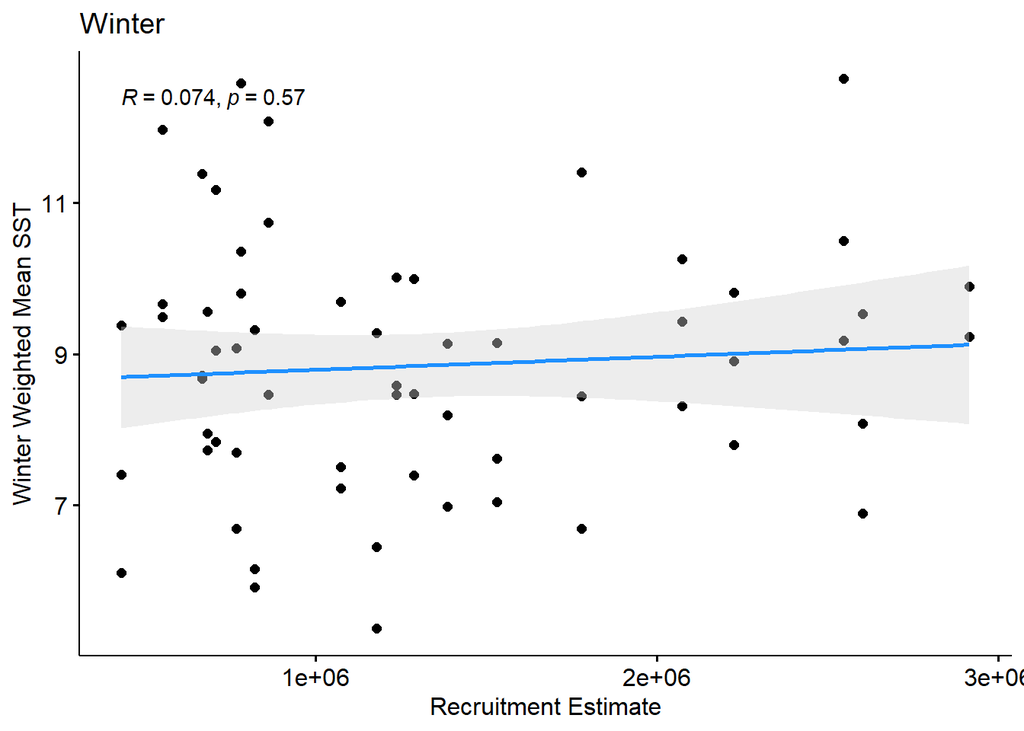

```r
ggscatter(sst_winter, x = "recruit_est", y = "weighted_mean_sst",
          add = "reg.line", conf.int = TRUE,
          cor.coef = TRUE, cor.coeff.args = list(method="pearson"),
          add.params=list(color="dodgerblue", fill="lightgray"),
          xlab = "Recruitment Estimate", ylab = "Winter Weighted Mean SST",
          title="Winter")
```

[figure not shown]

```r
sst.rec %>% filter(month %in% c(12,1,2)) %>%
  ggplot(aes(x = "recruit_est", y = "weighted_mean_sst",fill =month))+
           geom_point()
```

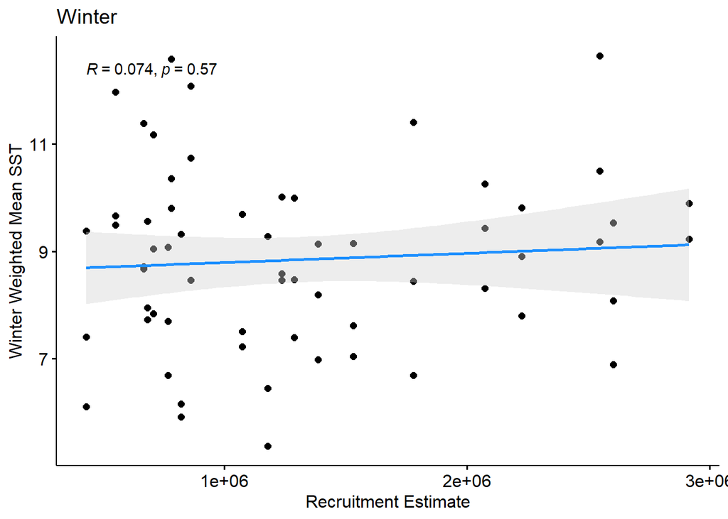

```r
ggscatter(sst_winter, x = "recruit_est", y = "weighted_mean_sst",
          add = "reg.line", conf.int = TRUE,
          cor.coef = TRUE, cor.coeff.args = list(method="pearson"),
          add.params=list(color="dodgerblue", fill="lightgray"),
          xlab = "Recruitment Estimate", ylab = "Winter Weighted Mean SST",
          title="Winter")
```

```r
## Spring
lm_spring<-lm(weighted_mean_sst ~ recruit_est, data=sst_spring)
summary(lm_spring)
```

```
##
## Call:
## lm(formula = weighted_mean_sst ~ recruit_est, data = sst_spring)
##
## Residuals:
##     Min      1Q  Median      3Q     Max
## -6.1147 -3.2854 -0.5526  3.7471  7.0917
##
## Coefficients:
##              Estimate Std. Error t value Pr(>|t|)
## (Intercept) 1.216e+01  1.012e+00  12.020   <2e-16 ***
## recruit_est 3.556e-07  6.644e-07   0.535    0.594
## ---
## Signif. codes:  0 '***' 0.001 '**' 0.01 '*' 0.05 '.' 0.1 ' ' 1
##
## Residual standard error: 3.828 on 61 degrees of freedom
## Multiple R-squared:  0.004674,   Adjusted R-squared:  -0.01164
## F-statistic: 0.2865 on 1 and 61 DF,  p-value: 0.5944
```

```r
cor.test(sst_spring$recruit_est, sst_spring$weighted_mean_sst, method=c("pearson"))
```

```
##
##  Pearson's product-moment correlation
##
## data:  sst_spring$recruit_est and sst_spring$weighted_mean_sst
## t = 0.53523, df = 61, p-value = 0.5944
## alternative hypothesis: true correlation is not equal to 0
## 95 percent confidence interval:
##  -0.1824868  0.3108685
## sample estimates:
##        cor
## 0.06836944
```

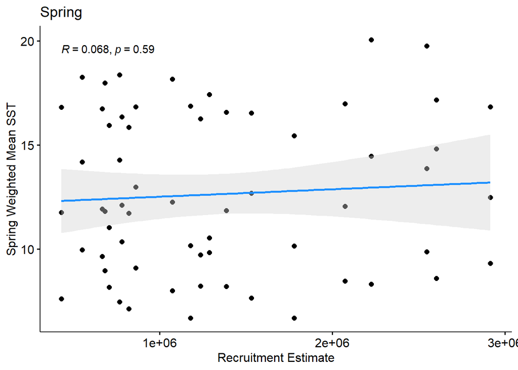

```r
ggscatter(sst_spring, x = "recruit_est", y = "weighted_mean_sst",
          add = "reg.line", conf.int = TRUE,
          cor.coef = TRUE, cor.coeff.args = list(method="pearson"),
          add.params=list(color="dodgerblue", fill="lightgray"),
          xlab = "Recruitment Estimate", ylab = "Spring Weighted Mean SST",
          title="Spring")
```

```r
## Summer
lm_summer<-lm(weighted_mean_sst ~ recruit_est, data=sst_summer)
summary(lm_summer)
```

```
##
## Call:
## lm(formula = weighted_mean_sst ~ recruit_est, data = sst_summer)
##
## Residuals:
##      Min       1Q   Median       3Q      Max
## -2.51168 -0.79996  0.01489  0.83898  2.73702
##
## Coefficients:
##              Estimate Std. Error t value Pr(>|t|)
## (Intercept) 2.280e+01  3.071e-01   74.25   <2e-16 ***
## recruit_est 5.850e-08  2.017e-07    0.29    0.773
## ---
## Signif. codes:  0 '***' 0.001 '**' 0.01 '*' 0.05 '.' 0.1 ' ' 1
##
## Residual standard error: 1.162 on 61 degrees of freedom
## Multiple R-squared:  0.001377,   Adjusted R-squared:  -0.01499
## F-statistic: 0.08411 on 1 and 61 DF,  p-value: 0.7728
```

```r
cor.test(sst_summer$recruit_est, sst_summer$weighted_mean_sst, method=c("pearson"))
```

```
##
##  Pearson's product-moment correlation
##
## data:  sst_summer$recruit_est and sst_summer$weighted_mean_sst
## t = 0.29003, df = 61, p-value = 0.7728
## alternative hypothesis: true correlation is not equal to 0
## 95 percent confidence interval:
##  -0.2126115  0.2822781
## sample estimates:
##        cor
## 0.03710834
```

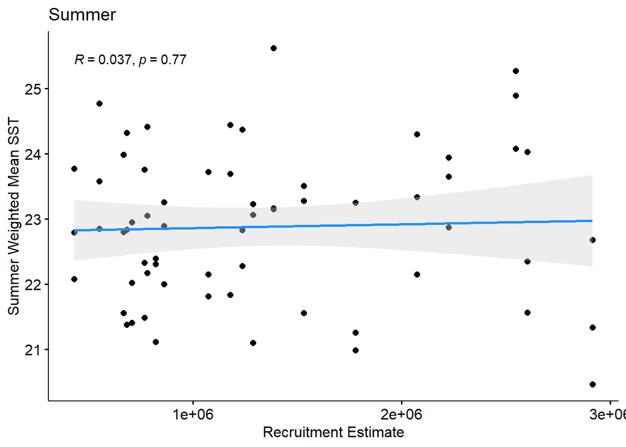

```r
ggscatter(sst_summer, x = "recruit_est", y = "weighted_mean_sst",
          add = "reg.line", conf.int = TRUE,
          cor.coef = TRUE, cor.coeff.args = list(method="pearson"),
          add.params=list(color="dodgerblue", fill="lightgray"),
          xlab = "Recruitment Estimate", ylab = "Summer Weighted Mean SST",
          title="Summer")
```

```r
## Fall
lm_fall<-lm(weighted_mean_sst ~ recruit_est, data=sst_fall)
summary(lm_fall)
```

```
##
## Call:
## lm(formula = weighted_mean_sst ~ recruit_est, data = sst_fall)
##
## Residuals:
##     Min      1Q  Median      3Q     Max
## -5.2757 -2.4013 -0.3087  2.5850  5.1703
##
## Coefficients:
##               Estimate Std. Error t value Pr(>|t|)
## (Intercept)  1.617e+01  8.010e-01  20.191   <2e-16 ***
## recruit_est -2.495e-07  5.262e-07  -0.474    0.637
## ---
## Signif. codes:  0 '***' 0.001 '**' 0.01 '*' 0.05 '.' 0.1 ' ' 1
##
## Residual standard error: 3.032 on 61 degrees of freedom
## Multiple R-squared:  0.003674,   Adjusted R-squared:  -0.01266
## F-statistic: 0.2249 on 1 and 61 DF,  p-value: 0.637
```

```r
cor.test(sst_fall$recruit_est, sst_fall$weighted_mean_sst, method=c("pearson"))
```

```
##
##  Pearson's product-moment correlation
##
## data:  sst_fall$recruit_est and sst_fall$weighted_mean_sst
## t = -0.47428, df = 61, p-value = 0.637
## alternative hypothesis: true correlation is not equal to 0
## 95 percent confidence interval:
##  -0.3038162  0.1900047
## sample estimates:
##         cor
## -0.06061386
```

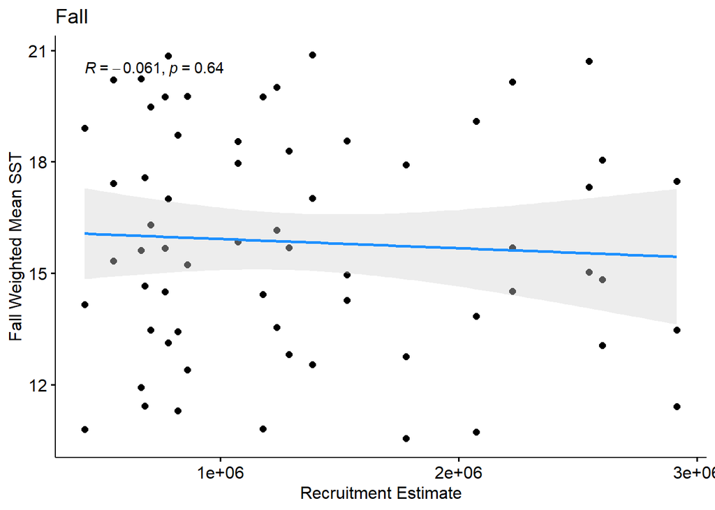

```r
ggscatter(sst_fall, x = "recruit_est", y = "weighted_mean_sst",
          add = "reg.line", conf.int = TRUE,
          cor.coef = TRUE, cor.coeff.args = list(method="pearson"),
          add.params=list(color="dodgerblue", fill="lightgray"),
          xlab = "Recruitment Estimate", ylab = "Fall Weighted Mean SST",
          title="Fall")
```

```r
## One year lag - Summer (peak spawn)
lm_lag<-lm(mean_sst_lag1 ~ recruit_est, data=sst_summer)
summary(lm_lag)
```

```
##
## Call:
## lm(formula = mean_sst_lag1 ~ recruit_est, data = sst_summer)
##
## Residuals:
##      Min       1Q   Median       3Q      Max
## -2.38712 -0.80602  0.09212  0.85112  2.75231
##
## Coefficients:
##               Estimate Std. Error t value Pr(>|t|)
## (Intercept)  2.295e+01  3.301e-01   69.53   <2e-16 ***
## recruit_est -6.760e-08  2.329e-07   -0.29    0.773
## ---
## Signif. codes:  0 '***' 0.001 '**' 0.01 '*' 0.05 '.' 0.1 ' ' 1
##
## Residual standard error: 1.173 on 58 degrees of freedom
##   (3 observations deleted due to missingness)
## Multiple R-squared:  0.001451,   Adjusted R-squared:  -0.01577
## F-statistic: 0.08425 on 1 and 58 DF,  p-value: 0.7727
```

```r
cor.test(sst_summer$recruit_est, sst_summer$mean_sst_lag1, method=c("pearson"))
```

```
##
##  Pearson's product-moment correlation
##
## data:  sst_summer$recruit_est and sst_summer$mean_sst_lag1
## t = -0.29026, df = 58, p-value = 0.7727
## alternative hypothesis: true correlation is not equal to 0
## 95 percent confidence interval:
##  -0.2892133  0.2179469
## sample estimates:
##         cor
## -0.03808556
```

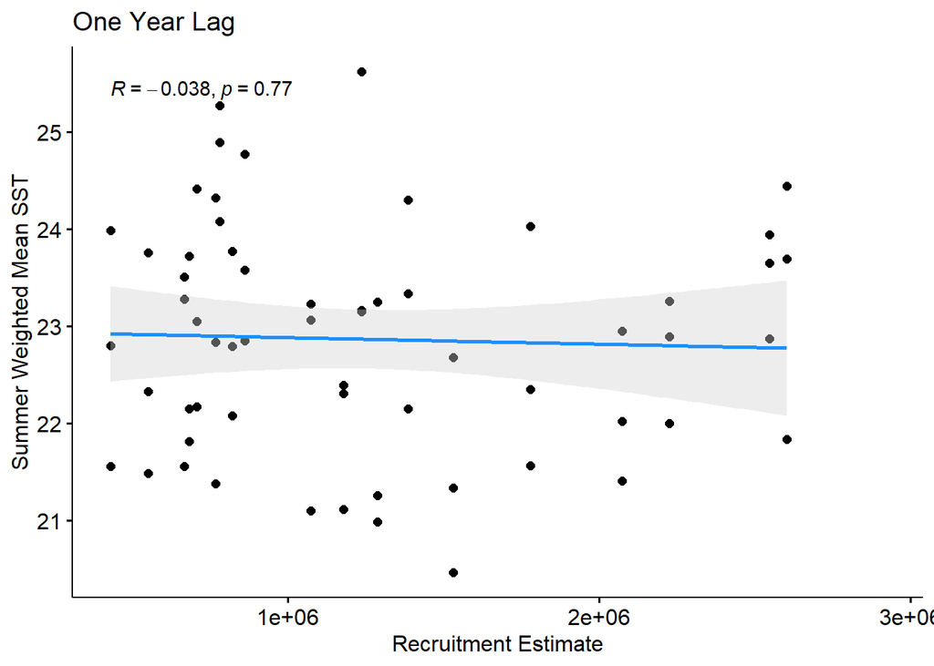

```r
ggscatter(sst_summer, x = "recruit_est", y = "mean_sst_lag1",
          add = "reg.line", conf.int = TRUE,
          cor.coef = TRUE, cor.coeff.args = list(method="pearson"),
          add.params=list(color="dodgerblue", fill="lightgray"),
          xlab = "Recruitment Estimate", ylab = "Summer Weighted Mean SST",
          title="One Year Lag")
```

Here we have SST in recruitment year - by month (updated 12/19)

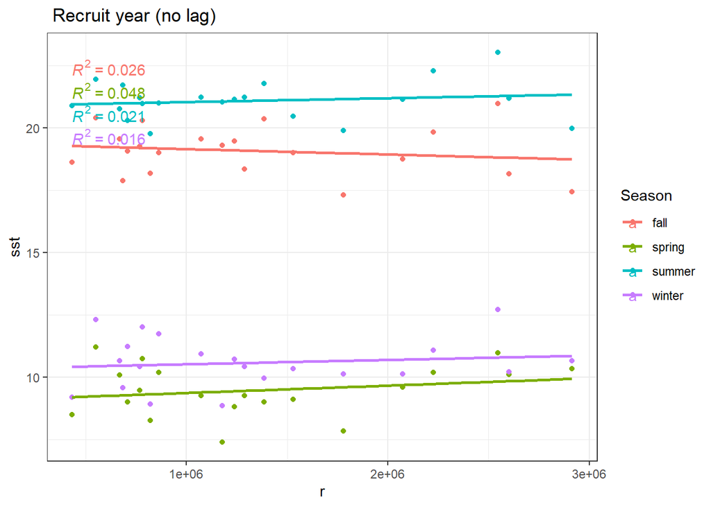

```r
df = sst.rec %>%
    mutate(season = case_when(month %in% c(12,1,2) ~ 'winter',
                              month %in% c(3,4,5) ~ 'spring',
                              month %in% c(6,7,8) ~ 'summer',
                              month %in% c(9,10,11) ~ 'fall'))


df %>% group_by(year, season) %>%
  summarize(sst = mean(weighted_mean_sst),
            r = mean(recruit_est)) %>%
ggplot2::ggplot(aes(x=r, y=sst, color = factor(season))) +
  geom_point() +
  geom_smooth(method = "lm", formula = y ~ x, size = 1, se = FALSE,
              aes(colour = factor(season)))  +
  labs(color = 'Season', title =' Recruit year (no lag)') +
  stat_cor(aes(label=..rr.label..)) +
  theme_bw() #+
```

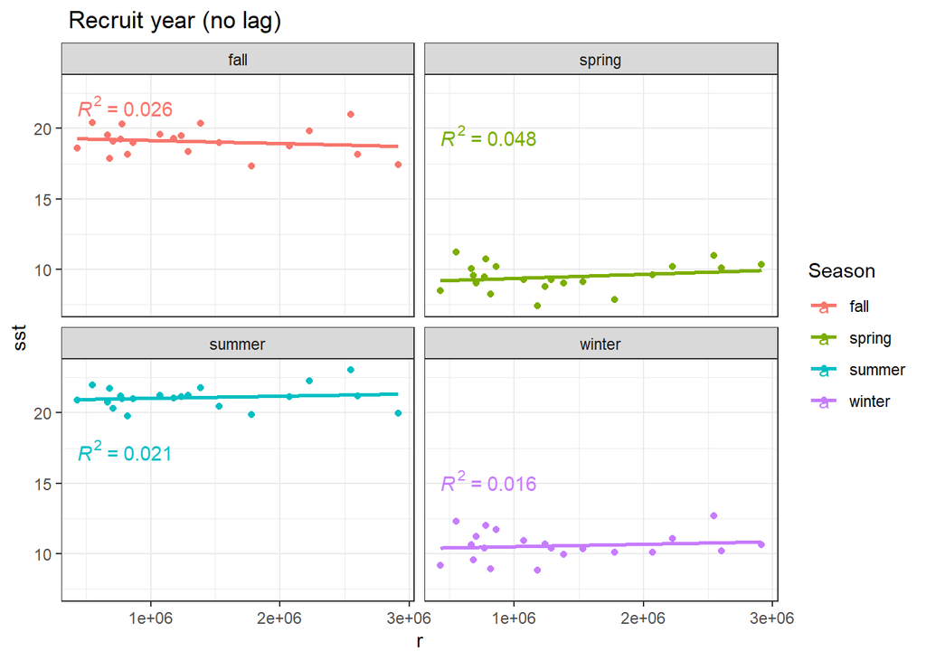

```r
  # facet_wrap(~season)


df %>% group_by(year, season) %>%
  summarize(sst = mean(weighted_mean_sst),
            r = mean(recruit_est)) %>%
  ggplot2::ggplot(aes(x=r, y=sst, color = factor(season))) +
  geom_point() +
  geom_smooth(method = "lm", formula = y ~ x, size = 1, se = FALSE,
              aes(colour = factor(season)))  +
  labs(color = 'Season', title = ' Recruit year (no lag)') +
  stat_cor(aes(label=..rr.label..)) +
  theme_bw() +
facet_wrap(~season)
```

Here we have SST lagged by 1 year - by month (updated 12/19)

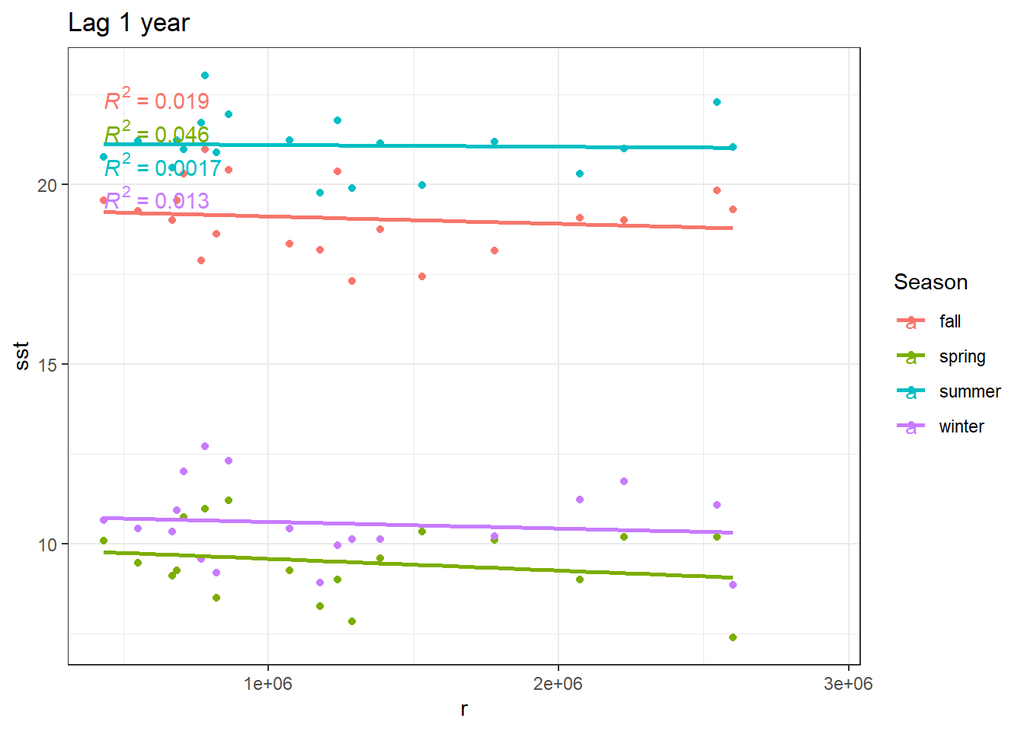

```r
df = sst.rec %>%
    mutate(season = case_when(month %in% c(12,1,2) ~ 'winter',
                              month %in% c(3,4,5) ~ 'spring',
                              month %in% c(6,7,8) ~ 'summer',
                              month %in% c(9,10,11) ~ 'fall'))


df %>% group_by(year, season) %>%
  summarize(sst = mean(mean_sst_lag1),
            r = mean(recruit_est)) %>%
ggplot2::ggplot(aes(x=r, y=sst, color = factor(season))) +
  geom_point() +
  geom_smooth(method = "lm", formula = y ~ x, size = 1, se = FALSE,
              aes(colour = factor(season)))  +
  labs(color = 'Season', title = 'Lag 1 year') +
  stat_cor(aes(label=..rr.label..)) +
  theme_bw() #+
```

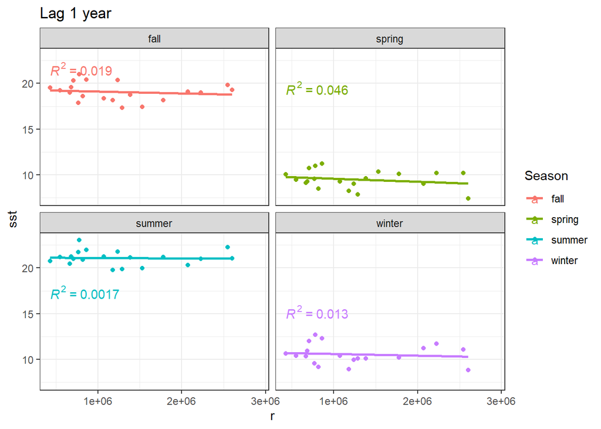

```r
  # facet_wrap(~season)


df %>% group_by(year, season) %>%
  summarize(sst = mean(mean_sst_lag1),
            r = mean(recruit_est)) %>%
  ggplot2::ggplot(aes(x=r, y=sst, color = factor(season))) +
  geom_point() +
  geom_smooth(method = "lm", formula = y ~ x, size = 1, se = FALSE,
              aes(colour = factor(season)))  +
  labs(color = 'Season', title = 'Lag 1 year') +
  stat_cor(aes(label=..rr.label..)) +
  theme_bw() +
facet_wrap(~season)
```

##### Bottom T analysis

- Note here temperatures are averaged across all depths > 50 for each month.

**Stephanie- Updated BT**

```r
bt <- read.csv(here::here('data/bottom_temp/bt_ts_gtf_1970_2023.csv'))

# BT with year lag
bt.lag <- bt %>%
  mutate(mean_bt_lag1 = lag(weighted_mean_bt,12))

# Join with recruit estimate
bt.rec <- dplyr::full_join(recruit, bt.lag, by = join_by(year)) %>%
  dplyr::select(year, month, recruit_est, weighted_mean_bt, mean_bt_lag1) %>%
  tidyr::drop_na()

#by season
bt_winter <- filter(bt.rec, month %in% c(1,2,3))
bt_spring <- filter(bt.rec, month %in% c(4,5,6))
bt_summer <- filter(bt.rec, month %in% c(7,8,9))
bt_fall <- filter(bt.rec, month %in% c(10,11,12))

## One year lag - Summer (peak spawn)
lm_lag<-lm(mean_bt_lag1 ~ recruit_est, data=bt_summer)
summary(lm_lag)
```

```
##
## Call:
## lm(formula = mean_bt_lag1 ~ recruit_est, data = bt_summer)
##
## Residuals:
##      Min       1Q   Median       3Q      Max
## -2.06292 -0.51469 -0.03642  0.58348  2.34287
##
## Coefficients:
##              Estimate Std. Error t value Pr(>|t|)
## (Intercept) 1.132e+01  1.607e-01  70.446   <2e-16 ***
## recruit_est 4.113e-08  9.760e-08   0.421    0.674
## ---
## Signif. codes:  0 '***' 0.001 '**' 0.01 '*' 0.05 '.' 0.1 ' ' 1
##
## Residual standard error: 0.8584 on 148 degrees of freedom
## Multiple R-squared:  0.001198,   Adjusted R-squared:  -0.00555
## F-statistic: 0.1776 on 1 and 148 DF,  p-value: 0.6741
```

```r
cor.test(bt_summer$recruit_est, bt_summer$mean_bt_lag1, method=c("pearson"))
```

```
##
##  Pearson's product-moment correlation
##
## data:  bt_summer$recruit_est and bt_summer$mean_bt_lag1
## t = 0.42137, df = 148, p-value = 0.6741
## alternative hypothesis: true correlation is not equal to 0
## 95 percent confidence interval:
##  -0.1263470  0.1938018
## sample estimates:
##        cor
## 0.03461544
```

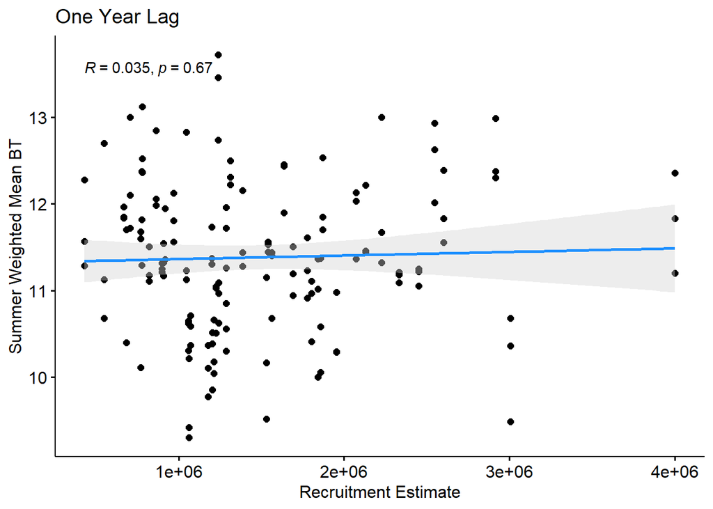

```r
ggscatter(bt_summer, x = "recruit_est", y = "mean_bt_lag1",
          add = "reg.line", conf.int = TRUE,
          cor.coef = TRUE, cor.coeff.args = list(method="pearson"),
          add.params=list(color="dodgerblue", fill="lightgray"),
          xlab = "Recruitment Estimate", ylab = "Summer Weighted Mean BT",
          title="One Year Lag")
```

```r
## Winter
lm_winter<-lm(weighted_mean_bt ~ recruit_est, data=bt_winter)
summary(lm_winter)
```

```
##
## Call:
## lm(formula = weighted_mean_bt ~ recruit_est, data = bt_winter)
##
## Residuals:
##     Min      1Q  Median      3Q     Max
## -4.3049 -0.5043  0.0847  0.6136  2.3256
##
## Coefficients:
##               Estimate Std. Error t value Pr(>|t|)
## (Intercept)  1.103e+01  1.922e-01  57.362   <2e-16 ***
## recruit_est -7.229e-08  1.167e-07  -0.619    0.537
## ---
## Signif. codes:  0 '***' 0.001 '**' 0.01 '*' 0.05 '.' 0.1 ' ' 1
##
## Residual standard error: 1.027 on 148 degrees of freedom
## Multiple R-squared:  0.002586,   Adjusted R-squared:  -0.004154
## F-statistic: 0.3837 on 1 and 148 DF,  p-value: 0.5366
```

```r
cor.test(bt_winter$recruit_est, bt_winter$weighted_mean_bt, method=c("pearson"))
```

```
##
##  Pearson's product-moment correlation
##
## data:  bt_winter$recruit_est and bt_winter$weighted_mean_bt
## t = -0.6194, df = 148, p-value = 0.5366
## alternative hypothesis: true correlation is not equal to 0
## 95 percent confidence interval:
##  -0.2094032  0.1103123
## sample estimates:
##         cor
## -0.05084811
```

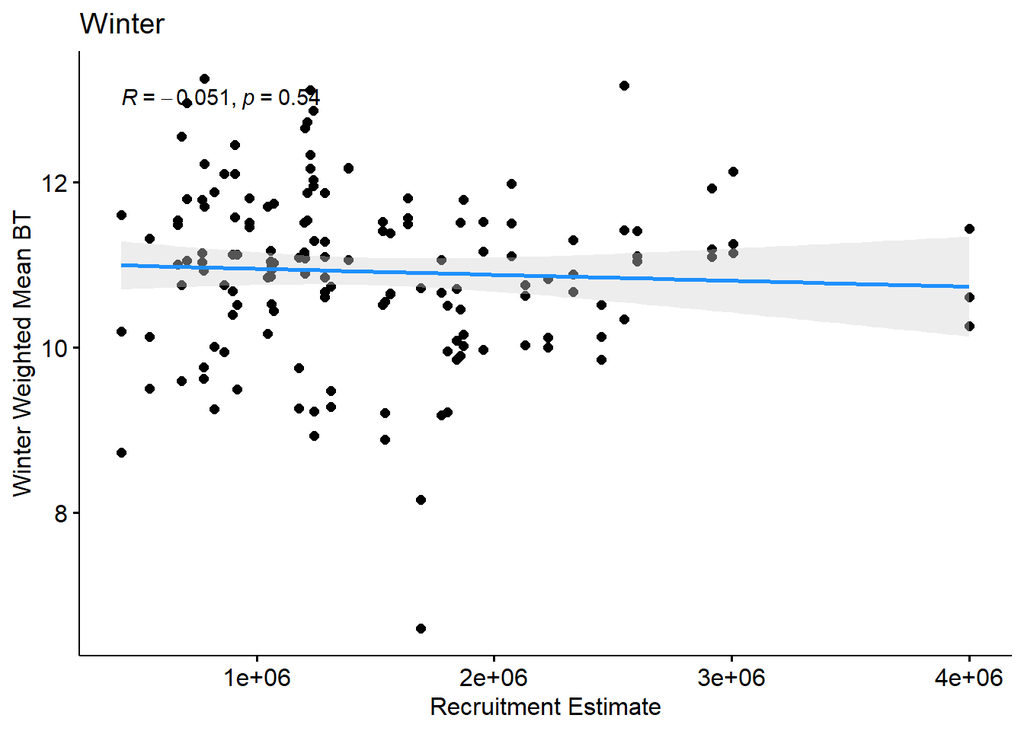

```r
ggscatter(bt_winter, x = "recruit_est", y = "weighted_mean_bt",
          add = "reg.line", conf.int = TRUE,
          cor.coef = TRUE, cor.coeff.args = list(method="pearson"),
          add.params=list(color="dodgerblue", fill="lightgray"),
          xlab = "Recruitment Estimate", ylab = "Winter Weighted Mean BT",
          title="Winter")
```

```r
## Spring
lm_spring<-lm(weighted_mean_bt ~ recruit_est, data=bt_spring)
summary(lm_spring)
```

```
##
## Call:
## lm(formula = weighted_mean_bt ~ recruit_est, data = bt_spring)
##
## Residuals:
##      Min       1Q   Median       3Q      Max
## -3.10071 -0.52654  0.05163  0.58828  1.89777
##
## Coefficients:
##               Estimate Std. Error t value Pr(>|t|)
## (Intercept)  1.069e+01  1.723e-01  62.028   <2e-16 ***
## recruit_est -9.889e-10  1.046e-07  -0.009    0.992
## ---
## Signif. codes:  0 '***' 0.001 '**' 0.01 '*' 0.05 '.' 0.1 ' ' 1
##
## Residual standard error: 0.9201 on 148 degrees of freedom
## Multiple R-squared:  6.038e-07,  Adjusted R-squared:  -0.006756
## F-statistic: 8.937e-05 on 1 and 148 DF,  p-value: 0.9925
```

```r
cor.test(bt_spring$recruit_est, bt_spring$weighted_mean_bt, method=c("pearson"))
```

```
##
##  Pearson's product-moment correlation
##
## data:  bt_spring$recruit_est and bt_spring$weighted_mean_bt
## t = -0.0094533, df = 148, p-value = 0.9925
## alternative hypothesis: true correlation is not equal to 0
## 95 percent confidence interval:
##  -0.1610185  0.1595043
## sample estimates:
##           cor
## -0.0007770595
```

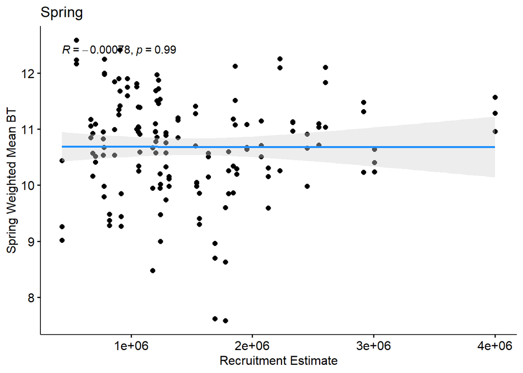

```r
ggscatter(bt_spring, x = "recruit_est", y = "weighted_mean_bt",
          add = "reg.line", conf.int = TRUE,
          cor.coef = TRUE, cor.coeff.args = list(method="pearson"),
          add.params=list(color="dodgerblue", fill="lightgray"),
          xlab = "Recruitment Estimate", ylab = "Spring Weighted Mean BT",
          title="Spring")
```

```r
## Summer
lm_summer<-lm(weighted_mean_bt ~ recruit_est, data=bt_summer)
summary(lm_summer)
```

```
##
## Call:
## lm(formula = weighted_mean_bt ~ recruit_est, data = bt_summer)
##
## Residuals:
##      Min       1Q   Median       3Q      Max
## -2.08669 -0.49696 -0.03112  0.56100  2.31676
##
## Coefficients:
##              Estimate Std. Error t value Pr(>|t|)
## (Intercept) 1.137e+01  1.606e-01  70.823   <2e-16 ***
## recruit_est 2.023e-08  9.750e-08   0.208    0.836
## ---
## Signif. codes:  0 '***' 0.001 '**' 0.01 '*' 0.05 '.' 0.1 ' ' 1
##
## Residual standard error: 0.8575 on 148 degrees of freedom
## Multiple R-squared:  0.0002909,  Adjusted R-squared:  -0.006464
## F-statistic: 0.04307 on 1 and 148 DF,  p-value: 0.8359
```

```r
cor.test(bt_summer$recruit_est, bt_summer$weighted_mean_bt, method=c("pearson"))
```

```
##
##  Pearson's product-moment correlation
##
## data:  bt_summer$recruit_est and bt_summer$weighted_mean_bt
## t = 0.20752, df = 148, p-value = 0.8359
## alternative hypothesis: true correlation is not equal to 0
## 95 percent confidence interval:
##  -0.1435984  0.1768338
## sample estimates:
##        cor
## 0.01705567
```

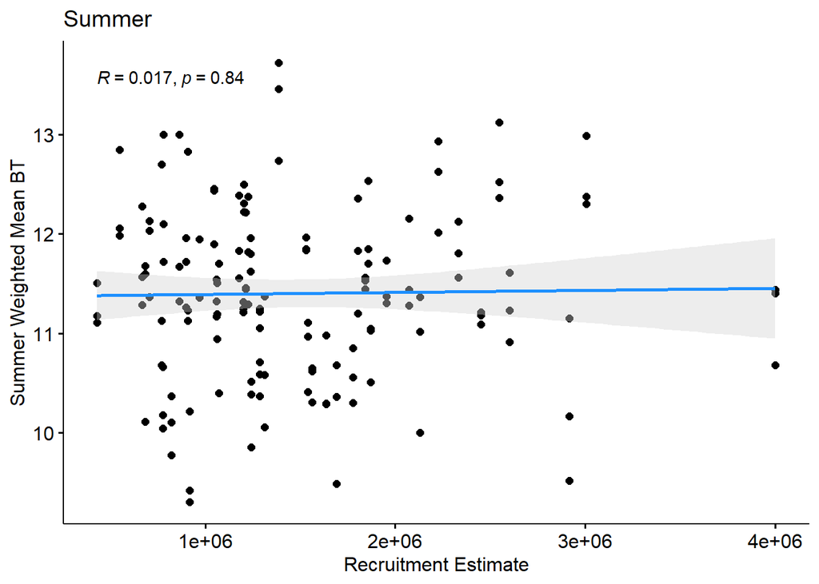

```r
ggscatter(bt_summer, x = "recruit_est", y = "weighted_mean_bt",
          add = "reg.line", conf.int = TRUE,
          cor.coef = TRUE, cor.coeff.args = list(method="pearson"),
          add.params=list(color="dodgerblue", fill="lightgray"),
          xlab = "Recruitment Estimate", ylab = "Summer Weighted Mean BT",
          title="Summer")
```

```r
## Fall
lm_fall<-lm(weighted_mean_bt ~ recruit_est, data=bt_fall)
summary(lm_fall)
```

```
##
## Call:
## lm(formula = weighted_mean_bt ~ recruit_est, data = bt_fall)
##
## Residuals:
##      Min       1Q   Median       3Q      Max
## -3.08506 -0.62604 -0.06512  0.61777  2.22327
##
## Coefficients:
##               Estimate Std. Error t value Pr(>|t|)
## (Intercept)  1.219e+01  1.852e-01  65.819   <2e-16 ***
## recruit_est -5.380e-08  1.125e-07  -0.478    0.633
## ---
## Signif. codes:  0 '***' 0.001 '**' 0.01 '*' 0.05 '.' 0.1 ' ' 1
##
## Residual standard error: 0.9891 on 148 degrees of freedom
## Multiple R-squared:  0.001544,   Adjusted R-squared:  -0.005202
## F-statistic: 0.2289 on 1 and 148 DF,  p-value: 0.6331
```

```r
cor.test(bt_fall$recruit_est, bt_fall$weighted_mean_bt, method=c("pearson"))
```

```
##
##  Pearson's product-moment correlation
##
## data:  bt_fall$recruit_est and bt_fall$weighted_mean_bt
## t = -0.47839, df = 148, p-value = 0.6331
## alternative hypothesis: true correlation is not equal to 0
## 95 percent confidence interval:
##  -0.1983061  0.1217348
## sample estimates:
##        cor
## -0.0392933
```

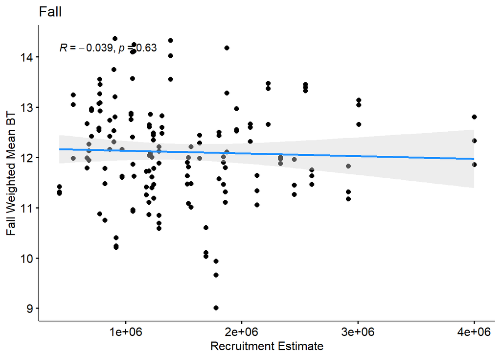

```r
ggscatter(bt_fall, x = "recruit_est", y = "weighted_mean_bt",
          add = "reg.line", conf.int = TRUE,
          cor.coef = TRUE, cor.coeff.args = list(method="pearson"),
          add.params=list(color="dodgerblue", fill="lightgray"),
          xlab = "Recruitment Estimate", ylab = "Fall Weighted Mean BT",
          title="Fall")
```

Here is bottom temp and recruitment not lagged

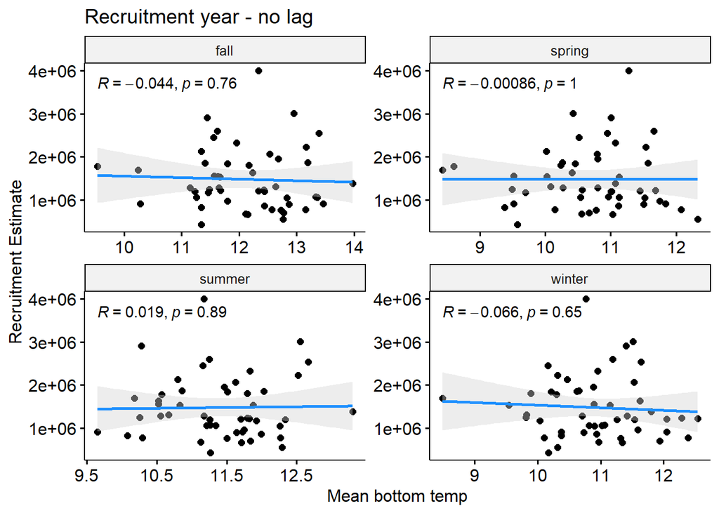

```r
df = bt.rec %>%
  mutate(season = case_when(month %in% c(1,2,3) ~ 'winter',
                            month %in% c(4,5,6) ~ 'spring',
                            month %in% c(7,8,9) ~ 'summer',
                            month %in% c(10,11,12) ~ 'fall'))


df %>% group_by(year, season) %>%
  summarize(bt = mean(weighted_mean_bt),
            r = mean(recruit_est)) %>%
  ggscatter(x = "bt", y = "r",
            add = "reg.line", conf.int = TRUE,
            cor.coef = TRUE, cor.coeff.args = list(method="pearson"),
            add.params=list(color="dodgerblue", fill="lightgray"),
            xlab = "Mean bottom temp", ylab = "Recruitment Estimate",
            title="Recruitment year - no lag")+
  facet_wrap(~season, scales = 'free')
```

Here we have BT lagged by 1 year - by month (updated 12/19)

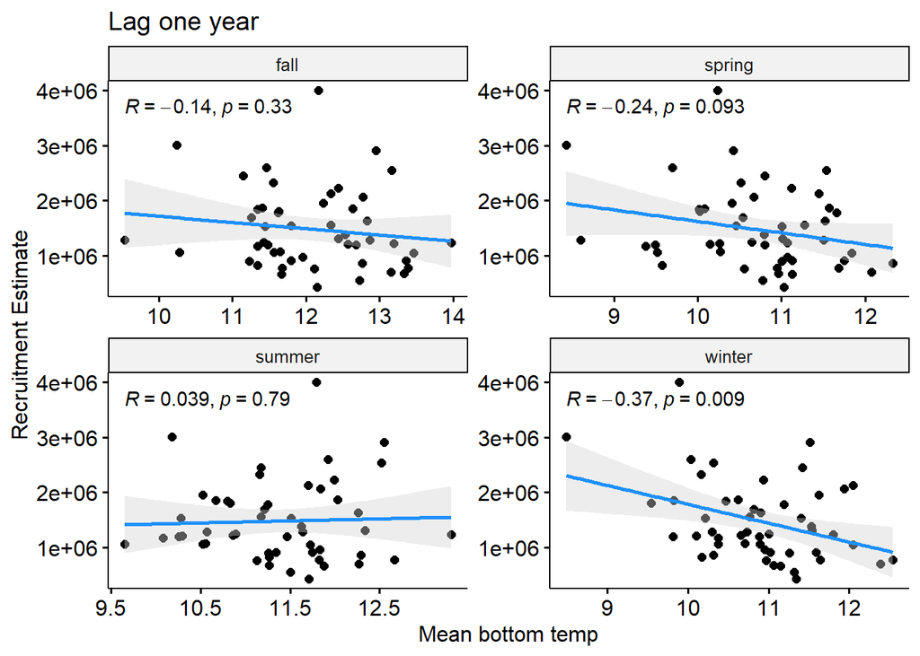

```r
# df = bt.rec %>%
#   mutate(season = case_when(month %in% c(1,2,3) ~ 'winter',
#                             month %in% c(4,5,6) ~ 'spring',
#                             month %in% c(7,8,9) ~ 'summer',
#                             month %in% c(10,11,12) ~ 'fall'))


df %>% group_by(year, season) %>%
  summarize(bt = mean(mean_bt_lag1),
            r = mean(recruit_est)) %>%
  ggscatter(x = "bt", y = "r",
            add = "reg.line", conf.int = TRUE,
            cor.coef = TRUE, cor.coeff.args = list(method="pearson"),
            add.params=list(color="dodgerblue", fill="lightgray"),
            xlab = "Mean bottom temp", ylab = "Recruitment Estimate",
            title="Lag one year")+
  facet_wrap(~season, scales = 'free')
```

##### Salinity

Here we explore salinity from the GLORYS reanalysis model at three different depths

- 78 meters (relevant to larvae, recruits)
- 92 meters (relevant recruits, juveniles)
- 110 meters (relevant to juveniles, adults)

##### Salinity analysis

78 Meters

```r
# Read in data at 78 m depth
sal78 <- read.csv(here::here('data/salinity/sal_78m_monthly_ts_gtf.csv'))

# BT with year lag
sal78.lag <- sal78 %>%
  mutate(mean_sal78_lag1 = lag(weighted_mean_sal_78m,12),
         year = as.numeric(year))

# Join with recruit estimate
sal78.rec <- dplyr::full_join(recruit, sal78.lag, by = join_by(year)) %>%
  dplyr::select(year, month, recruit_est, weighted_mean_sal_78m, mean_sal78_lag1) %>%
  tidyr::drop_na()
```

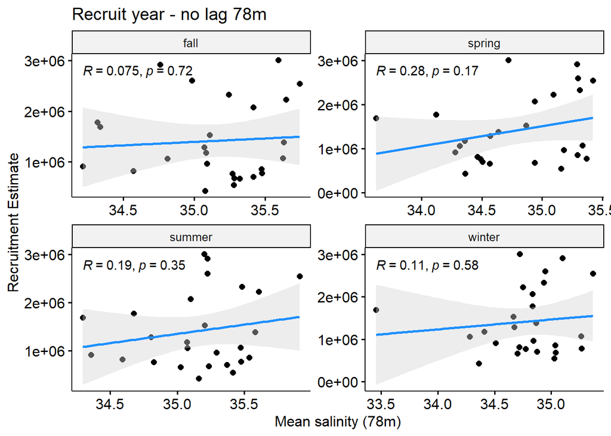

```r
df = sal78.rec %>%
  mutate(season = case_when(month %in% c(1,2,3) ~ 'winter',
                            month %in% c(4,5,6) ~ 'spring',
                            month %in% c(7,8,9) ~ 'summer',
                            month %in% c(10,11,12) ~ 'fall'))
# Plot without lag
df %>% group_by(year, season) %>%
  summarize(sst = mean(weighted_mean_sal_78m),
            r = mean(recruit_est)) %>%
  ggscatter(x = "sst", y = "r",
            add = "reg.line", conf.int = TRUE,
            cor.coef = TRUE, cor.coeff.args = list(method="pearson"),
            add.params=list(color="dodgerblue", fill="lightgray"),
            xlab = "Mean salinity (78m)", ylab = "Recruitment Estimate",
            title="Recruit year - no lag 78m")+
  facet_wrap(~season, scales = 'free')
```

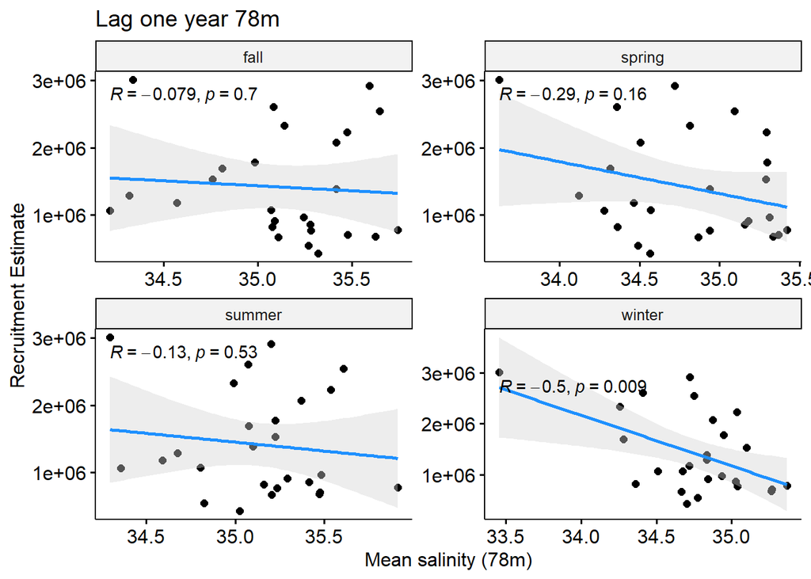

```r
# Plot with lag
df %>% group_by(year, season) %>%
  summarize(sst = mean(mean_sal78_lag1),
            r = mean(recruit_est)) %>%
  ggscatter(x = "sst", y = "r",
            add = "reg.line", conf.int = TRUE,
            cor.coef = TRUE, cor.coeff.args = list(method="pearson"),
            add.params=list(color="dodgerblue", fill="lightgray"),
            xlab = "Mean salinity (78m)", ylab = "Recruitment Estimate",
            title="Lag one year 78m")+
  facet_wrap(~season, scales = 'free')
```

```r
#### Computing correlations
# win.cor = df %>% filter(season == 'winter')
# print(paste0('correlation coeff: ', round(cor(win.cor[,3], win.cor[,5]), 4)))
# fal.cor = df %>% filter(season == 'fall')
# print(paste0('correlation coeff: ', round(cor(fal.cor[,3], fal.cor[,4]), 4)))
```

92 Meters

```r
# Read in data at 92 meter depth

sal92 <- read.csv(here::here('data/salinity/sal_92m_monthly_ts_gtf.csv'))

# BT with year lag
sal92.lag <- sal92 %>%
  mutate(mean_sal92_lag1 = lag(weighted_mean_sal_92m,12),
         year = as.numeric(year))

# Join with recruit estimate
sal92.rec <- dplyr::full_join(recruit, sal92.lag, by = join_by(year)) %>%
  dplyr::select(year, month, recruit_est, weighted_mean_sal_92m, mean_sal92_lag1) %>%
  tidyr::drop_na()
```

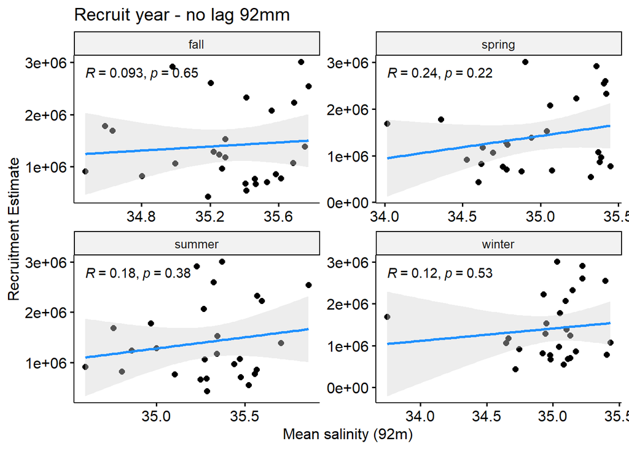

```r
df = sal92.rec %>%
  mutate(season = case_when(month %in% c(1,2,3) ~ 'winter',
                            month %in% c(4,5,6) ~ 'spring',
                            month %in% c(7,8,9) ~ 'summer',
                            month %in% c(10,11,12) ~ 'fall'))

# Plot without lag
df %>% group_by(year, season) %>%
  summarize(sst = mean(weighted_mean_sal_92m),
            r = mean(recruit_est)) %>%
  ggscatter(x = "sst", y = "r",
            add = "reg.line", conf.int = TRUE,
            cor.coef = TRUE, cor.coeff.args = list(method="pearson"),
            add.params=list(color="dodgerblue", fill="lightgray"),
            xlab = "Mean salinity (92m)", ylab = "Recruitment Estimate",
            title="Recruit year - no lag 92mm")+
  facet_wrap(~season, scales = 'free')
```

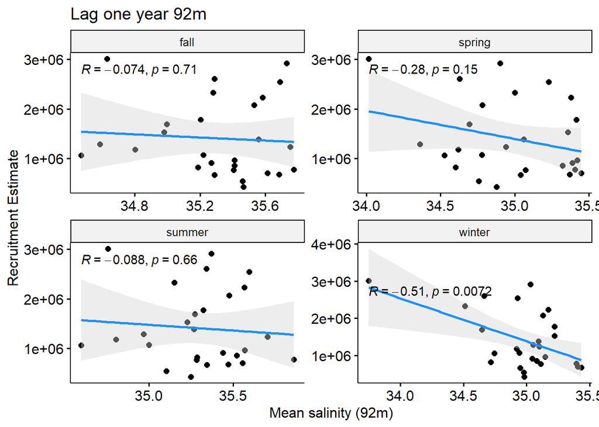

```r
# Plot with lag
df %>% group_by(year, season) %>%
  summarize(sst = mean(mean_sal92_lag1),
            r = mean(recruit_est)) %>%
  ggscatter(x = "sst", y = "r",
            add = "reg.line", conf.int = TRUE,
            cor.coef = TRUE, cor.coeff.args = list(method="pearson"),
            add.params=list(color="dodgerblue", fill="lightgray"),
            xlab = "Mean salinity (92m)", ylab = "Recruitment Estimate",
            title="Lag one year 92m")+
  facet_wrap(~season, scales = 'free')
```

```r
#### Computing correlations
# win.cor = df %>% filter(season == 'winter')
# print(paste0('correlation coeff: ', round(cor(win.cor[,3], win.cor[,5]), 4)))
# fal.cor = df %>% filter(season == 'fall')
# print(paste0('correlation coeff: ', round(cor(fal.cor[,3], fal.cor[,4]), 4)))
```

110 Meters

```r
# Wrangling the data
sal110 <- read.csv(here::here('data/salinity/sal_110m_monthly_ts_gtf.csv'))

# BT with year lag
sal110.lag <- sal110 %>%
  mutate(mean_sal110_lag1 = lag(weighted_mean_sal_110m,12),
         year = as.numeric(year))

# Join with recruit estimate
sal110.rec <- dplyr::full_join(recruit, sal110.lag, by = join_by(year)) %>%
  dplyr::select(year, month, recruit_est, weighted_mean_sal_110m, mean_sal110_lag1) %>%
  tidyr::drop_na()
```

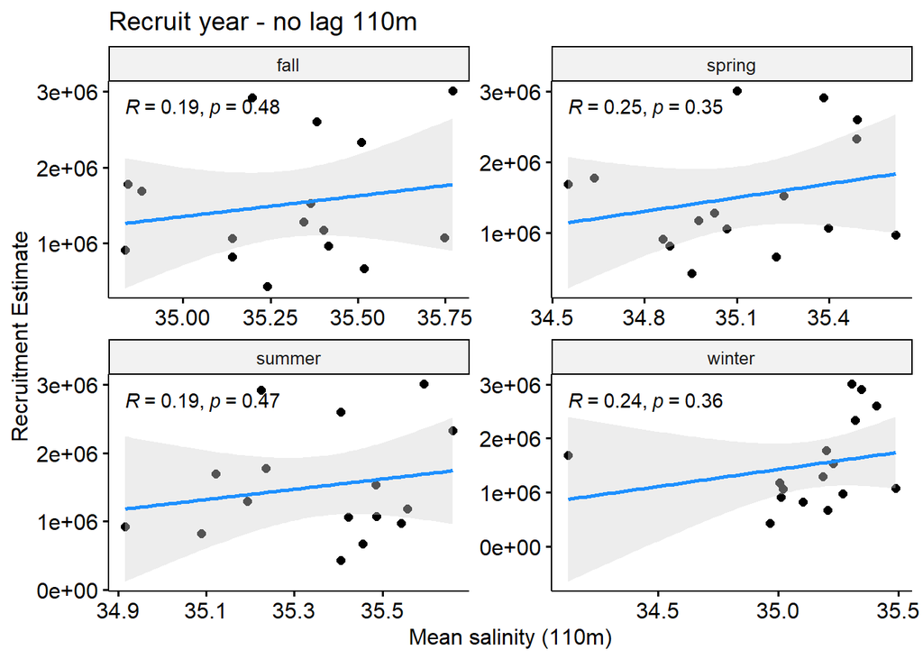

```r
# Add a category for month
df = sal110.rec %>%
  mutate(season = case_when(month %in% c(1,2,3) ~ 'winter',
                            month %in% c(4,5,6) ~ 'spring',
                            month %in% c(7,8,9) ~ 'summer',
                            month %in% c(10,11,12) ~ 'fall'))

# Plot without lag
df %>% group_by(year, season) %>%
  summarize(sst = mean(weighted_mean_sal_110m),
            r = mean(recruit_est)) %>%
  ggscatter(x = "sst", y = "r",
            add = "reg.line", conf.int = TRUE,
            cor.coef = TRUE, cor.coeff.args = list(method="pearson"),
            add.params=list(color="dodgerblue", fill="lightgray"),
            xlab = "Mean salinity (110m)", ylab = "Recruitment Estimate",
            title="Recruit year - no lag 110m")+
  facet_wrap(~season, scales = 'free')
```

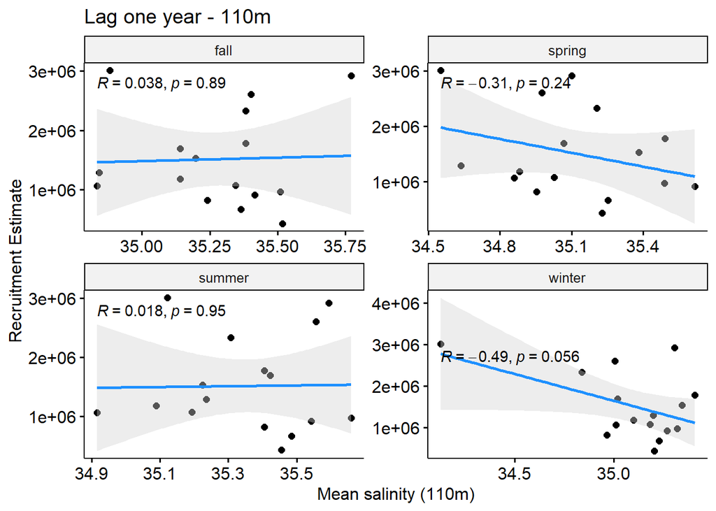

```r
# Plot with lag
df %>% group_by(year, season) %>%
  summarize(sst = mean(mean_sal110_lag1),
            r = mean(recruit_est)) %>%
  ggscatter(x = "sst", y = "r",
            add = "reg.line", conf.int = TRUE,
            cor.coef = TRUE, cor.coeff.args = list(method="pearson"),
            add.params=list(color="dodgerblue", fill="lightgray"),
            xlab = "Mean salinity (110m)", ylab = "Recruitment Estimate",
            title="Lag one year - 110m")+
  facet_wrap(~season, scales = 'free')
```

```r
#### Computing correlations
# win.cor = df %>% filter(season == 'winter')
# print(paste0('correlation coeff: ', round(cor(win.cor[,3], win.cor[,5]), 4)))
# fal.cor = df %>% filter(season == 'fall')
# print(paste0('correlation coeff: ', round(cor(fal.cor[,3], fal.cor[,4]), 4)))
```

##### Cold pool analysis

Excerpt from New York Bight Fish, Fisheries, and Sand Features: Data Review Volume 1: Literature Synthesis and Gap Analysis:

Natural events are documented for Scup (Morse 1978; Smith and Norcross 1968), Bluefish (Slater et al. 2007), and Northern Puffer (Wicklund 1970) in the MAB and NYB as a result of upwelling of cold bottom water, and for Golden Tilefish on the OCS from eastward flow of the Cold Pool (Fisher et al. 2014). Such events are difficult to detect and quantify because they are episodic, because they could happen in winter when there are few observers, or because they leave dead animals on the bottom instead of floating (Fisher et al.2014) so that they are only detected incidentally by trawler (e.g., Woodhead (1964)).

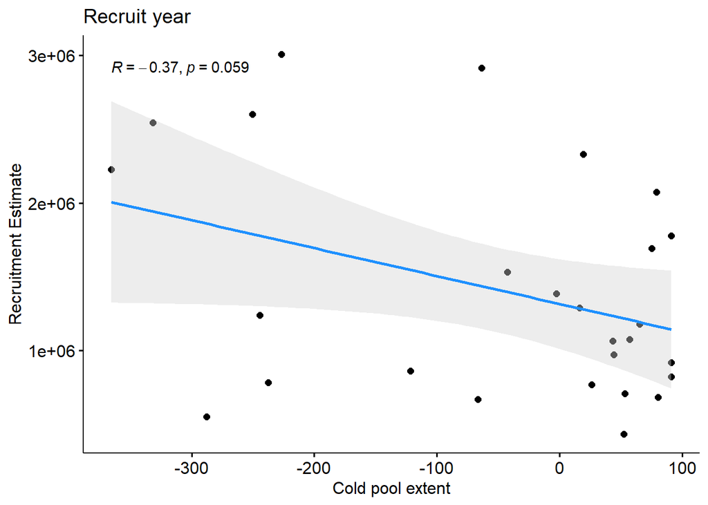

```r
library(ecodata)
# Pull cold pool data
cp.ex <- ecodata::cold_pool
# Selecting just the extent
cp <- cp.ex %>% filter(Time %in% c(1994:2020),
              Var == 'extent_index') %>%
  mutate(ext = Value,
         ext_lag1 = lag(ext,1),
         year = as.numeric(Time))
## NOTE: I added more lags (up to 7), but they only got worse - may make more
## sense to do more lags with cpue data with older fish


# Join with recruit estimate
cp.rec <- dplyr::full_join(recruit, cp, by = join_by(year)) %>%
  dplyr::select(year, recruit_est, ext, ext_lag1) %>%
  filter(year %in% c(1994:2020))

cp.rec %>%
  ggscatter(x = 'ext', y = 'recruit_est',
            add = "reg.line", conf.int = TRUE,
            cor.coef = TRUE, cor.coeff.args = list(method="pearson"),
            add.params=list(color="dodgerblue", fill="lightgray"),
            xlab = "Cold pool extent", ylab = "Recruitment Estimate",
            title="Recruit year")
```

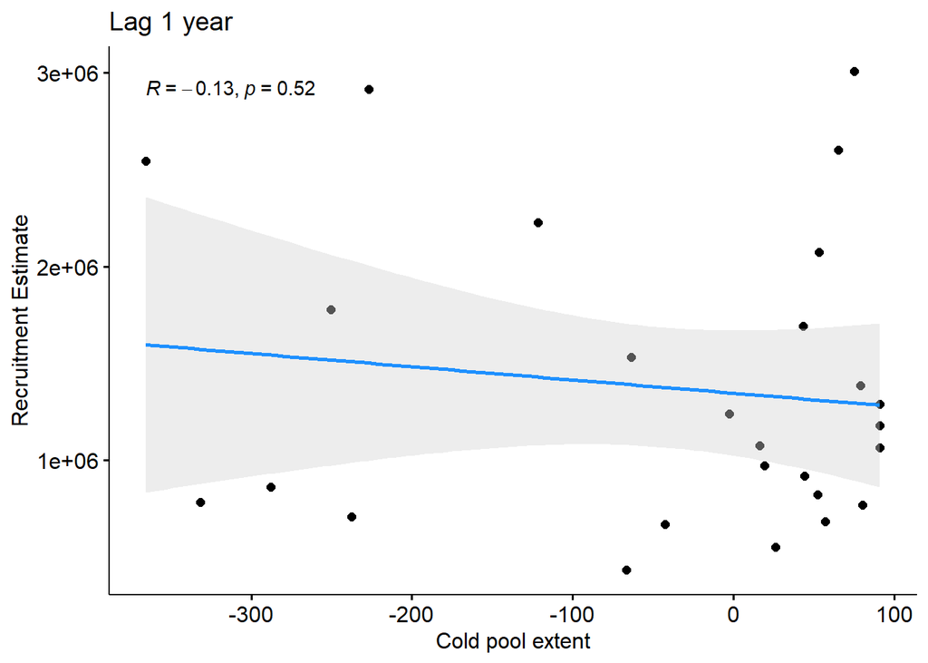

```r
cp.rec %>%
  ggscatter(x = 'ext_lag1', y = 'recruit_est',
            add = "reg.line", conf.int = TRUE,
            cor.coef = TRUE, cor.coeff.args = list(method="pearson"),
            add.params=list(color="dodgerblue", fill="lightgray"),
            xlab = "Cold pool extent", ylab = "Recruitment Estimate",
            title="Lag 1 year")
```

#### Currents

Cross-shelf processes may influence the retention or displacement of tilefish during early life history stages. These are explored below.

##### Shelf water volume

Shelf water volume: A measure of the volume of water bounded inshore of the shelf-slope front. In this analysis, shelf water is defined as all water having salinity <34 psu. The position of the shelf-slope front varies inter-annually with the higher shelf water values indicating the front being pushed further towards the shelf break.

high shv: front pushed towards sbf low shv: front pushed inshore (more slope water on shelf)

Hypothesis: Higher recruitment success correlated with years of higher shelf water volume in spring/summer. These months months may be particularly important as that is when spawning is occurring and the position of the sbf may influence the position of larvae (away from spawning grounds).

Additional variables in this dataset are shelf water temperature and salinity which may also be indicative of habitat conditions.

```r
# Shelf water volume
shlfvol <- read.csv(here::here('data/shelf_water_volume/ShelfWaterVolume_BSB_update.csv'))

# wrangling date info, converting doy to date and month
yrs <- as.vector(nrow(shlfvol))
shlfvol$Year <- as.character(shlfvol$Year)
for (i in 1:nrow(shlfvol)){
  yrs[i] <- strsplit(shlfvol$Year, ".", fixed = TRUE)[[i]][1]
}
shlfvol$year <- yrs

shlfvol <- shlfvol %>% mutate(date_= as.Date(Year.Day-1,
                                             origin=paste0(year, "-01-01")),
                              month= strftime(date_, "%m"),
                              day=strftime(date_,"%d"),
                              year = as.integer(year),
                              month = as.numeric(month))


# Create shw vol by month w/lag
df.lag = shlfvol %>%
  group_by(year,month) %>%
  summarise(mean_t = mean(ShW.T),
            mean_s = mean(ShW.S),
            mean_v = mean(ShW.Vol)) %>%
  mutate(mean_t_lag2 = lag(mean_t,2),
         mean_t_lag3 = lag(mean_t,3),
         mean_t_lag6 = lag(mean_t,6),
         mean_s_lag2 = lag(mean_s,2),
         mean_s_lag3 = lag(mean_s,3),
         mean_s_lag6 = lag(mean_s,6),
         mean_v_lag2 = lag(mean_v,2),
         mean_v_lag3 = lag(mean_v,3),
         mean_v_lag6 = lag(mean_v,6))
# Join in-situ bottom temps w/assessment recruitment estimate
df.join.shlf = dplyr::full_join(recruit, df.lag, by = join_by(year)) %>%
  dplyr::select(year, month, recruit_est, mean_t, mean_s, mean_v,
                mean_t_lag2, mean_s_lag2, mean_v_lag2,
                mean_t_lag3, mean_s_lag3, mean_v_lag3) %>%
  tidyr::drop_na()
# See what months have data
sort(unique(df.join.shlf$month))
```

```
## [1]  7  8  9 10 11
```

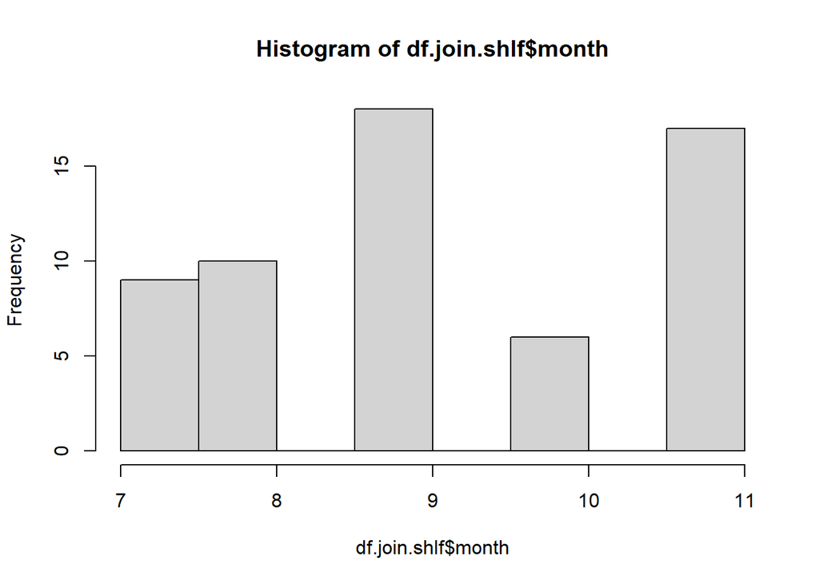

```r
hist(df.join.shlf$month) # will group into spring/summer fall/winter categories
```

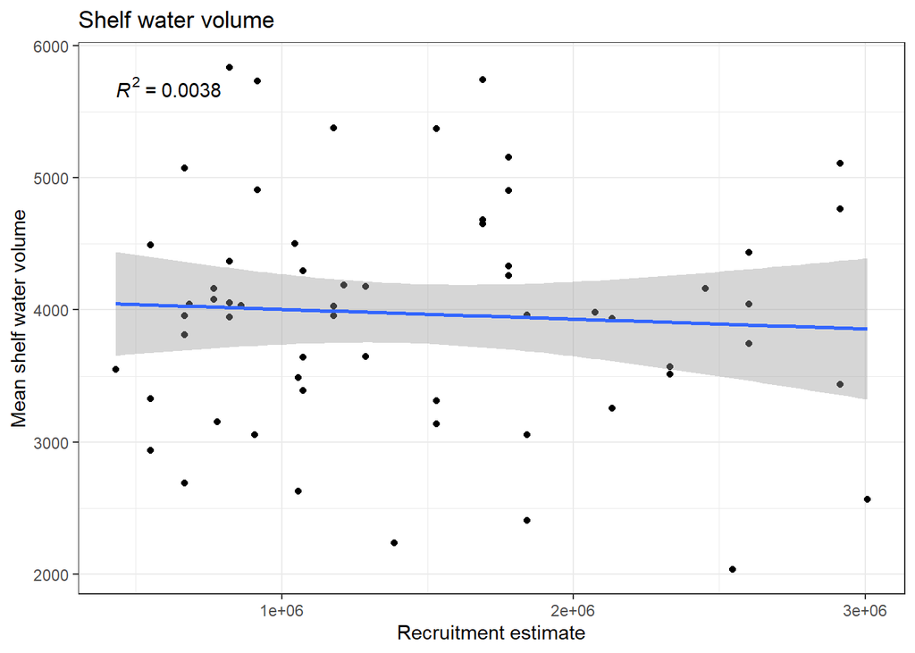

```r
## Shelf water volume no lag
ggplot2::ggplot(df.join.shlf,
                aes(x=recruit_est, y=mean_v)) +
  geom_point(color = 'black') +
  stat_smooth(method = "lm",
              formula = y ~ x,
              geom = "smooth") +
  xlab('Recruitment estimate') +
  ylab('Mean shelf water volume') +
  labs(title = 'Shelf water volume') +
  stat_cor(aes(label=..rr.label..)) +
  theme_bw()
```

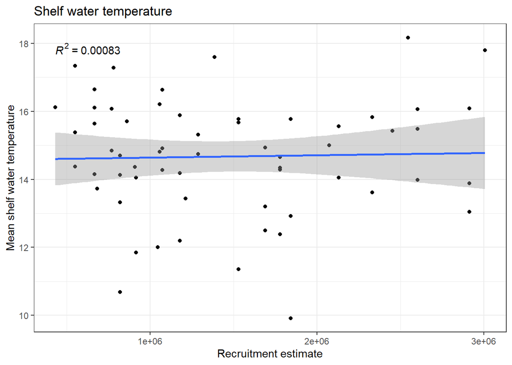

```r
## Shelf water temperature no lag
ggplot2::ggplot(df.join.shlf,
                aes(x=recruit_est, y=mean_t)) +
  geom_point(color = 'black') +
  stat_smooth(method = "lm",
              formula = y ~ x,
              geom = "smooth") +
  xlab('Recruitment estimate') +
  ylab('Mean shelf water temperature') +
  labs(title = 'Shelf water temperature') +
  stat_cor(aes(label=..rr.label..)) +
  theme_bw()
```

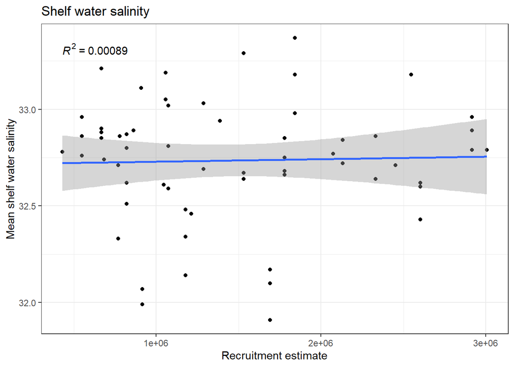

```r
## Shelf water salinity no lag
ggplot2::ggplot(df.join.shlf,
                aes(x=recruit_est, y=mean_s)) +
  geom_point(color = 'black') +
  stat_smooth(method = "lm",
              formula = y ~ x,
              geom = "smooth") +
  xlab('Recruitment estimate') +
  ylab('Mean shelf water salinity') +
  labs(title = 'Shelf water salinity') +
  stat_cor(aes(label=..rr.label..)) +
  theme_bw()
```

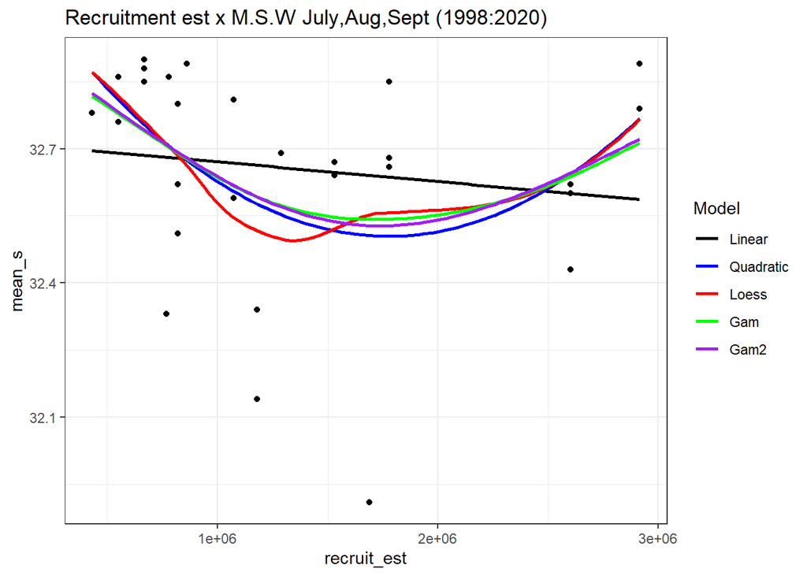

```r
ggplot2::ggplot(df.join.shlf %>% filter(year >1997 & month %in% c(7,8,9)),
                aes(x=recruit_est, y=mean_s)) +
  geom_point() +
  geom_smooth(method = "lm", formula = y ~ x, size = 1, se = FALSE,
              aes(colour = 'Linear')) +
  geom_smooth(method = "lm", formula = y ~ x + I(x^2),
              size = 1, se = FALSE, aes(colour = 'Quadratic')) +
  geom_smooth(method = "loess", formula = y ~ x,
              size = 1, se = FALSE, aes(colour = 'Loess')) +
  geom_smooth(method = "gam", formula = y ~  s(x),
              size = 1, se = FALSE, aes(colour = 'Gam')) +
  geom_smooth(method = "gam", formula = y ~ s(x, k = 3),
              size = 1, se = FALSE, aes(colour = 'Gam2')) +
  labs(title = 'Recruitment est x M.S.W July,Aug,Sept (1998:2020)') +
  scale_color_manual(name='Model',
                     breaks=c('Linear', 'Quadratic', 'Loess', 'Gam', 'Gam2'),
                     values=c('Linear'='black', 'Quadratic'='blue',
                              'Loess'='red', 'Gam' = 'green',
                              'Gam2' = 'purple')) +
  theme_bw()
```